# Pricing defaultable bonds in the shadow-intensity framework

Jean-Paul Renne

HEC Lausanne

# 1 The context

Pallara and Renne (2023) and Renne and Pallara (2023) investigate the pricing the sovereign credit risk in the context of shadow-intensity frameworks. In that type of framework, the prices of defaultable bonds are given by conditional expectations of the form:
$$\begin{equation}
\mathbb{E}_t(\exp[\color{blue}{-z_{t+1}-\dots-z_{t+h}}-\max(0,\lambda_{t+1})-\dots -\max(0,\lambda_{t+h})]),\tag{1.1}
\end{equation}$$
where $z_t$ (risk-free short-term rate) and $\lambda_t$ (*shadow default intensity*) are affine functions of the state vector $x_t$. In addition, $x_t$ follows a Gaussian vector auto-regressive (VAR) model. That is, we have:
$$\begin{eqnarray*}
z_t &=& \dot{a}'x_t + \dot{b}\\
\lambda_t &=& a'x_t + b,
\end{eqnarray*}$$
and
$$\begin{equation}
x_t = \mu + \Phi x_{t-1}+ \Sigma\varepsilon_t,\tag{1.2}
\end{equation}$$
with $\varepsilon_t \sim \mathcal{N}(0,Id)$ (where $Id$ denotes the identity matrix).

Equation (1.1) gives the risk-neutral price of a bond of maturity $h$, issued by an entity whose default intensity is $\underline{\lambda}_t = \max(0,\lambda_t)$. (That is, the conditional default probability of the issuer, on date $t$, is $1-\exp(-\underline{\lambda}_t)$.)

Absent the blue terms, the conditional expectations appearing in (1.1) would be of the same type as the ones considered in the shadow-rate literature (see Black (1995)). In that case, one could for instance use the approaches proposed by Priebsch (2013) or Wu and Xia (2016) to calculate approximations for these conditional expectations. Pallara and Renne (2023) and Renne and Pallara (2023) extend the approach of Wu and Xia (2016) to compute approximate values to (1.1). Th present page uses the latter approach, employing codes contained in package `TSModels` to implement this approach.

To start with, load package `TSModels`. This library is available on GitHub and can be accessed using the following lines of code:

```r
install.packages("devtools")
library(devtools)
install_github("jrenne/TSModels")
```

# 2 A numerical example

## 2.1 Specifications

Consider a two-factor model, that is $x_t = [x_{1,t},x_{2,t}]'$. Assume that $z_t$ (that can be interpreted as the risk-free short term rate) depends on $x_{1,t}$ only, and that $\lambda_t$ (the shadow default intensity) depends on $x_{2,t}$.

We consider the following VAR dynamics for $x_t$:
$$x_t = \left[\begin{array}{cc}0.9 & 0 \\ 0 & 0.9\end{array}\right] x_{t-1} +
\left[\begin{array}{cc}1 & 0.1 \\ 0 & 1\end{array}\right]\varepsilon_t,$$
which determines $\mu$, $\Phi$, and $\Sigma$ of (1.2).

Further, we want $z_t$ (respectively $\lambda_t$) to be of mean 2% (respectively 0) and of standard deviation $1\%$ (resp. 2/%).

Let us code these specifications:

```r
Phi_x <- .9 * diag(2) # set Phi
Sigma_x <- diag(2) # set Sigma
Sigma_x[1,2] <- .1
Mu_x <- matrix(0,2,1) # set mu

stdv.z      <- .01 # set the unconditional std dev of z
stdv.lambda <- .02 # set the unconditional std dev of lambda

# Compute the unconditional variance of x_t:
uncond.Variance.X <- matrix(solve(diag(2*2) - Phi_x %x% Phi_x) %*%
                              c(Sigma_x %*% t(Sigma_x)),2,2)

# Deduce a and a.dot:
a.dot <- matrix(c(stdv.z/sqrt(uncond.Variance.X[1,1]),0))
a     <- matrix(c(0,stdv.lambda/sqrt(uncond.Variance.X[2,2])))

# Set the unconditional means of and lambda:
b.dot <- .02
b     <- .0
```

## 2.2 Simulations

Let us have a look at simulated paths for $z_t$ and $\lambda_t$:

```r
library(TSModels)

nb.periods <- 200
X <- simul.X(Phi_x,Mu_x,Sigma_x,nb.periods)
z <- b.dot + a.dot[1] * X[1,1,]
lambda <- b + a[2] * X[2,1,]
```

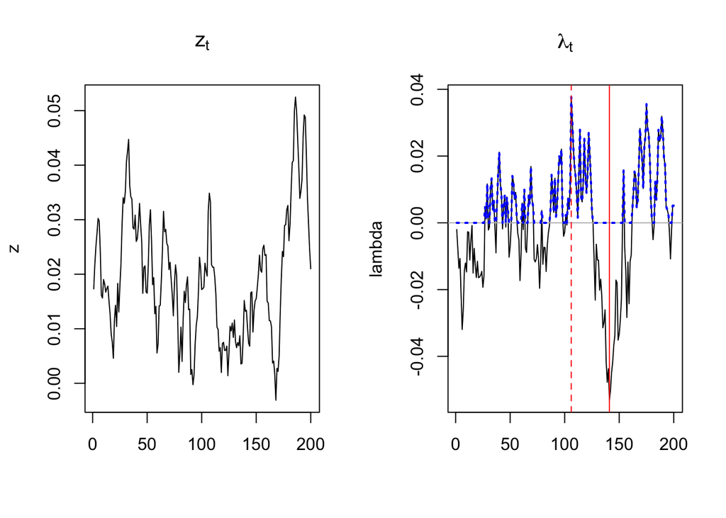

Figure 2.1: This plots simulated paths for $z_t$ (risk-free short-term rate) and $\lambda_t$ (shadow intensity). The blue dotted line, on the right-hand-side plot, is the effective intensity, that is $\max(0,\lambda_t)$. The vertical lines indicate those dates where lambda is minimal and maximal.

# 3 Bond pricing

Let us now evaluate the conditional expectations of (1.1), for $h=\{1,\dots,10\}$. For that, we make use of function `compute.condit.Exp` of package `TSModels`.

```r
H <- 10
res <- compute.condit.Exp(a,b,a.dot,b.dot,
                          Phi_x,Mu_x,Sigma_x,
                          X=cbind(X[1,1,],X[2,1,]),
                          max.h = H)
t.min.lambda <- which(lambda==min(lambda))
t.max.lambda <- which(lambda==max(lambda))
rbind(res$E.n[t.max.lambda,], #approximate values of the conditional expect. for date t
      -log(res$E.n[t.max.lambda,])/(1:H))
```

```
##            [,1]       [,2]       [,3]       [,4]       [,5]       [,6]
## [1,] 0.93776082 0.88336292 0.83545648 0.79295285 0.75496469 0.72077426
## [2,] 0.06426035 0.06200958 0.05992567 0.05799788 0.05621686 0.05457155
##           [,7]       [,8]       [,9]      [,10]
## [1,] 0.6897996 0.66156599 0.63568382 0.61183102
## [2,] 0.0530506 0.05164319 0.05033933 0.04912991
```

The last two lines respectively give, for the date featuring the highest $\lambda_t$, the term structures of the bond prices and of associated yields-to-maturity.

Let us now compute credit-risk-free bond prices. This is obtained by taking $a=0$ and $b=0$ (so that $\lambda_t=0$):

```r
res0 <- compute.condit.Exp(a*0.00001,b*0.00001,a.dot,b.dot,
                          Phi_x,Mu_x,Sigma_x,
                          X=cbind(X[1,1,],X[2,1,]),
                          max.h = H)
y       <- - log(res$E.n) / t(matrix(1:H,H,nb.periods))
y_RF    <- - log(res0$E.n) / t(matrix(1:H,H,nb.periods))
spreads <- y - y_RF
```

Let us plot the term strcutures of yields and spreads for the date on which we observe the highest $\lambda_t$:

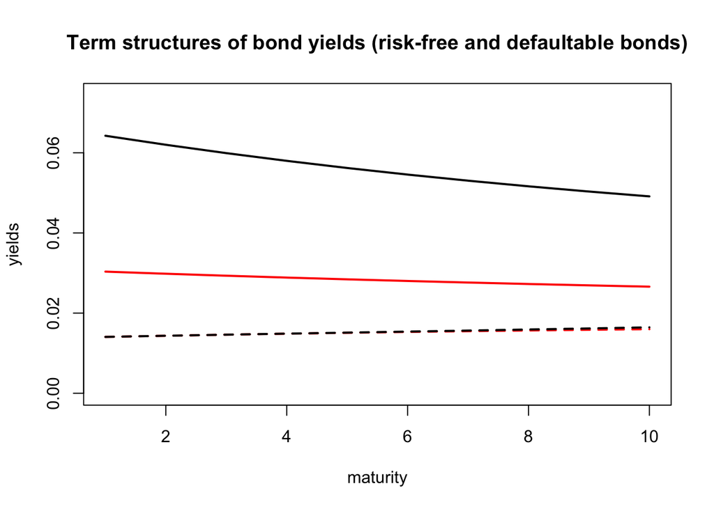

Figure 3.1: Term structures of risk-free yields (in red), and credit-risky yields (in black). Solid lines (respectively dashed lines) correspond to the date where $\lambda_t$ is the highest (resp. the lowest). These two dates are indicated by vertical lines on the previous figure.

```r
plot(y[t.max.lambda,],type="l",ylim=c(0,max(y)),xlab="maturity",ylab="yields",
     main="Term structures of bond yields (risk-free and defaultable bonds)",lwd=2)
lines(y_RF[t.max.lambda,],col="red",lwd=2)
lines(y_RF[t.min.lambda,],col="red",lwd=2,lty=2)
lines(y[t.min.lambda,],lwd=2,lty=2)
```

# 4 Check formula using simulations

In this section, we calculate the conditional expectation given in (1.1) using Monte-Carlo simulations, for different maturities $h$. We will then compare these prices with the ones resulting from function `compute.condit.Exp`.

We consider the date on which $\lambda_t$ is the highest.

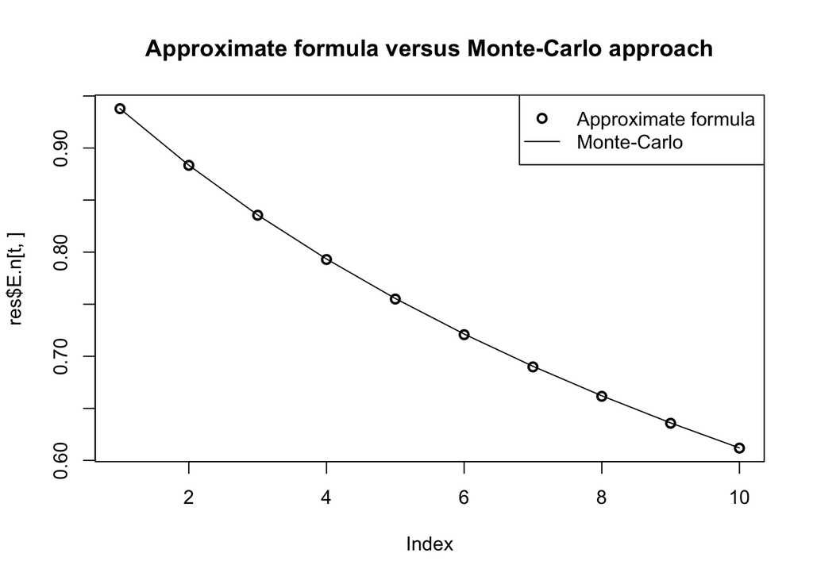

Figure 4.1: Comparison between formula-based prices and Monte-Carlo-based defaultable bond prices.

```r
nb.replics <- 10000 # Number of simulated trajectories
t  <- t.max.lambda # date on which cond. expect. are computed
Xt <- matrix(X[,1,t],ncol=1) # state vector on that date

# Simulate trajectories starting from Xt:
X <- simul.X(Phi_x,Mu_x,Sigma_x,nb.periods=H,X0 = Xt,nb.replics = nb.replics)
# Compute prices for each trajectory:
aux1 <- apply(X,c(2,3),function(x){exp(- b.dot - t(x)%*%a.dot -
                                        pmax(0,b + t(x)%*%a))})
aux2 <- apply(aux1,1,cumprod)
# Compute averages of prices across simulated trajectories:
simul.prices <- apply(aux2,1,mean)
# Compare with output of compute.condit.Exp:
plot(res$E.n[t,],lwd=2,main="Approximate formula versus Monte-Carlo approach")
lines(simul.prices)
legend("topright",c("Approximate formula","Monte-Carlo"),lty=c(NaN,1),pch=c(1,NaN),lwd=c(2,1))
```

# References

Black, Fischer. 1995. “Interest Rates as Options.” *Journal of Finance* 50 (5): 1371–76. https://www.jstor.org/stable/2329320.

Pallara, Kevin, and Jean-Paul Renne. 2023. “Fiscal Limits and the Pricing of Eurobonds.” *Management Science* 0 (0): null. https://doi.org/10.1287/mnsc.2023.4740.

Priebsch, Marcel A. 2013. “Computing Arbitrage-Free Yields in Multi-Factor Gaussian Shadow-Rate Term Structure Models.” Finance and Economics Discussion Series 2013-63. Board of Governors of the Federal Reserve System (U.S.). http://ideas.repec.org/p/fip/fedgfe/2013-63.html.

Renne, Jean-Paul, and Kevin Pallara. 2023. “Fiscal Fatigue, Fiscal Limits and Sovereign Credit Spreads.” University of Lausanne. https://papers.ssrn.com/sol3/papers.cfm?abstract_id=3475425.

Wu, Jing Cynthia, and Fan Dora Xia. 2016. “Measuring the Macroeconomic Impact of Monetary Policy at the Zero Lower Bound.” *Journal of Money, Credit and Banking* 48 (2-3): 253–91. https://onlinelibrary.wiley.com/doi/abs/10.1111/jmcb.12300.